# 02-exercises

Christopher Brown

April 13, 2016

This exercise uses the **Fuel Economy** data set from the **AppliedPredicitiveModeling** package.

## Exercise 1

Hint: See `?cars2010`

- After the **Fuel Economy** data is loaded, combine three data sets into one data set. (Note: The name `dat` is very often used in these situations, `data` is a reserved R word.)

```r
dat <- bind_rows(cars2010, cars2011, cars2012)
```

- What is a good “naive guess” of FE? Show your work

```r
naive_guess <- mean(dat$FE)
```

- plot FE (Fuel Econonomy) vs. EngDisp. Plot the naive guess.

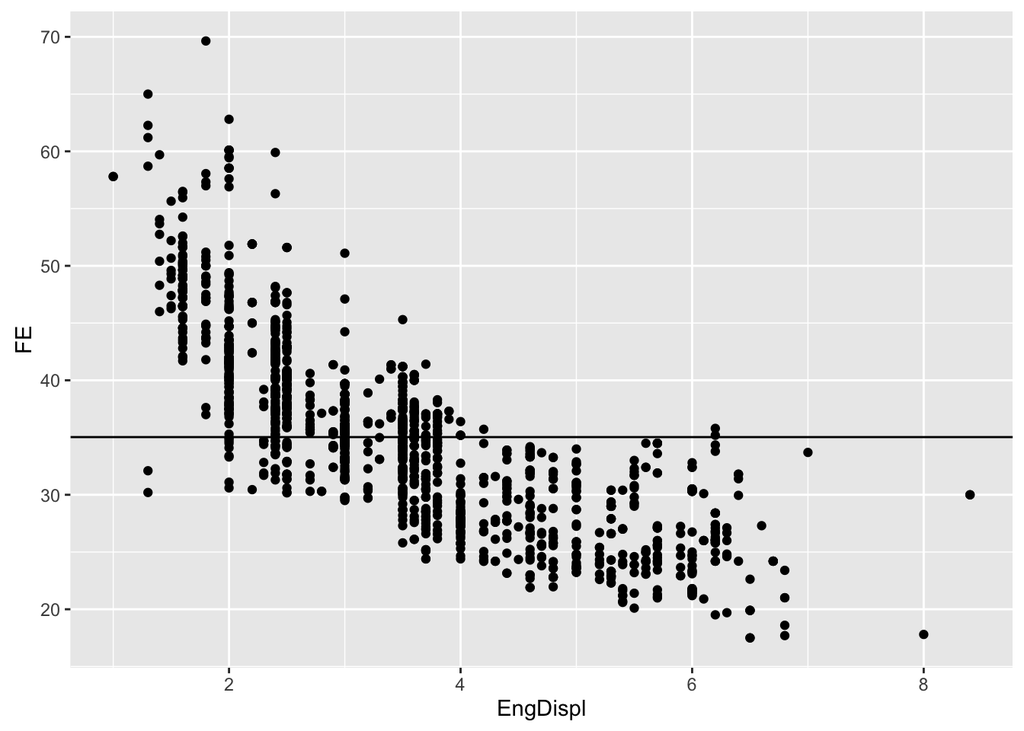

```r
# ... ggplot2
ggplot(data=dat, aes(x=EngDispl, y=FE)) + geom_point()  + geom_hline(yintercept = naive_guess)
```

- Sample 10 observations from `dat`
- Plot this data. Add a line for the naive_guess.

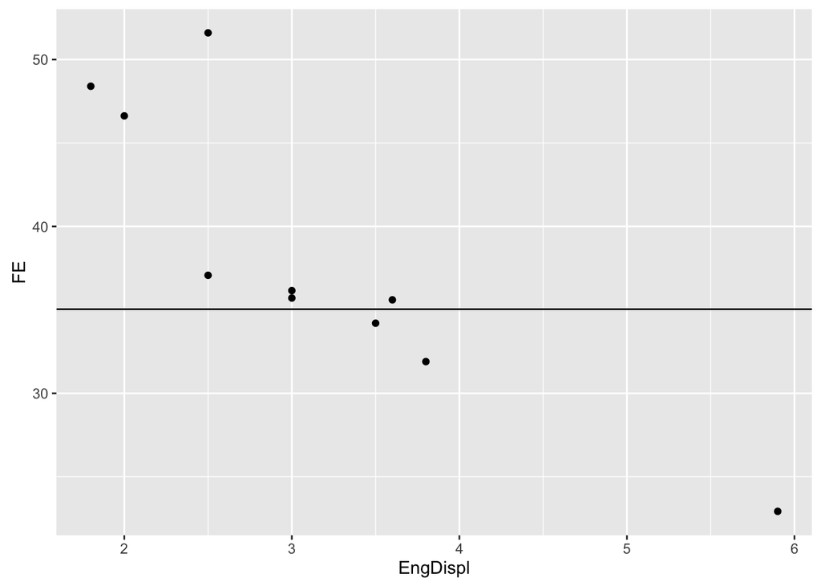

```r
set.seed(314)

# Sample
samp <- dat %>% dplyr::sample_n(10)

# Plots
samp %>% ggplot(aes(x=EngDispl, y=FE))  + geom_point() + geom_hline(yintercept = naive_guess)
```

## Exercise 2:

Write a loss functions for calculating: - Root Mean Square Error - Mean Absolute Error - Median Absolute Error

All functions should accept two arguments:

```r
rmse <- function(y, yhat) {
  (y- yhat) ^2 %>% mean %>% sqrt
}

mae <- function(y, yhat) {
  abs(y - yhat) %>% mean
}

medae <- function(y, yhat) {
  abs(y - yhat) %>% median
}
```

Use these functions to evaluate the loss/performance of: - the naive guess

```r
rmse(dat$FE, naive_guess)
```

```
## [1] 8.096176
```

```r
mae(dat$FE, naive_guess)
```

```
## [1] 6.319942
```

```r
medae(dat$FE, naive_guess)
```

```
## [1] 5.238326
```

## Exercise 3: Linear Model and Model Performance

- Use `lm` to create a linear model fitting the relationship between FE and EngDispl for the cars2010 data set

```r
fit.2010 <- lm(FE ~ EngDispl, data=cars2010)
```

- Use your functions to evaluate the training error
- Use your model to: – predict the FE for 2011. What is the RMSE errors associated with the predictions. – predict the FE for 2012. What is the RMSE errors associated with the predictions.

```r
y.2010 <- predict(fit.2010, newdata = cars2010)
y.2011 <- predict(fit.2010, newdata = cars2011)
y.2012 <- predict(fit.2010, newdata = cars2012)

rmse.2010 <- rmse(cars2010$FE, y.2010)
rmse.2011 <- rmse(cars2011$FE, y.2011)
rmse.2012 <- rmse(cars2012$FE, y.2012)
```

```r
# DO NOT EDIT
rmse.2010
```

```
## [1] 4.620076
```

```r
rmse.2011
```

```
## [1] 5.162531
```

```r
rmse.2012
```

```
## [1] 6.63853
```

## Exercise 4:

- Model the fuel economy (`FE`) as a function of `EngDispl`, `NumCyl` and `VarValve` using the `cars2011` data set.
- Provide betas

```r
fit.2010 <- lm(FE ~ EngDispl + NumCyl + VarValveTiming, data=cars2011)
betas <- summary(fit.2010)$coefficients[, 1]
```

[output not shown]